# Walkshed analysis - Los Angeles Example

Carole Voulgaris

9/17/2021

# Setup

You’ll need to increase the memory for R5R and load the required libraries.

```r
# increase memory for r5r
options(java.parameters = "-Xmx2G")

library(sf) # spatial data package
library(tidycensus) # for retrieving census data
library(tidyverse) # for everything
library(r5r) # for getting transit sf features and calculating walk times
```

# Get census data (with geometry)

In this example, I’m just getting a set of race/ethnicity variables for each census block.

I’m also generating a set of points for the centroid of each census block. Since I’ll be using those centroid points to build a travel time matrix, I’ll need to rename the `GEOID` column to be called `id` and tranform the data to WGS 84 (both requirements of the `travel_time_matrix()` function in R5R).

```r
pop_by_race = c(total = "P005001",
                nh_white = "P005003",
                nh_black = "P005004",
                nh_asian = "P005006",
                hispanic = "P005010")

la_blocks <- get_decennial(geography = "block",
                           state = "CA",
                           county = "Los Angeles",
                           variables = pop_by_race,
                           geometry = TRUE,
                           output = "wide") %>%
  st_transform(crs = "WGS84")

la_centroids <- st_centroid(la_blocks) %>%
  rename(id = "GEOID")
```

# Get transit route and stop locations

**Before running any of the following, you’ll need to make sure you have the GTFS network that was in place on Feb 1, 2020 in the `Networks/LA/1Feb` folder. That folder also needs to contain PBF file with the OpenStreetMap network for the area covered by the transit network.**

First, set up the R5R core.

```r
r5r_core <- setup_r5("Networks/LA/1Feb", verbose = FALSE)
```

Now, use R5R to extract the transit routes and stop locations. Since we’ll be using the stop locations to build a travel time matrix, we’ll need to change the name of the `stop_index` column to `id`.

```r
transit <- transit_network_to_sf(r5r_core)

transit_routes <- transit$routes

transit_stops <- transit$stops %>%
  rename(id = stop_index)
```

# Generate travel time matrix

We’ll build a travel time matrix to calculate the travel time from each transit stop to each census block centroid. We’re setting a maximum trip duration of ten minutes, so our matrix will only include census blocks within a ten-minute walk of a transit stop.

We’re done with R5R now, so we can free up some memory by stopping the R5R core.

```r
ttm <- travel_time_matrix(r5r_core = r5r_core,
                          origins = transit_stops,
                          destinations =la_centroids,
                          mode = "WALK",
                          max_trip_duration = 10,
                          verbose = FALSE)
stop_r5(r5r_core)
```

# Generate walksheds with route-level data

Now we’ll get all the unique GEOIDs from the `toId` column of the travel time matrix. This is a list of census blocks with a centroid within a 10-minute walk of a transit stop.

Then I’ll use that list to filter the LA County census blocks to only include those within walking distance of transit and do a spatial join to identify which transit route serves each of those blocks.

```r
transit_block_list <- unique(ttm$toId)

transit_blocks <- la_blocks %>%
  filter(GEOID %in% transit_block_list) %>%
  st_join(transit_routes, st_nearest_feature)
```

Now, I can combine all the blocks that serve the same route and calculate population totals and percentages within each route’s walkshed.

```r
transit_walksheds <- transit_blocks %>%
  group_by(route_id) %>%
  summarize(total = sum(total),
            nh_white = sum(nh_white),
            nh_black = sum(nh_black),
            nh_asian = sum(nh_asian),
            hispanic = sum(hispanic),
            geometry = st_union(geometry),
            route_id = first(route_id),
            short_name = first(short_name),
            mode = first(mode)) %>%
  mutate(pct_nh_white = 100 * nh_white / total,
         pct_nh_black = 100 * nh_black / total,
         pct_nh_asian = 100 * nh_asian / total,
         pct_hispanic = 100 * hispanic / total)
```

Now I can plot the results on a map.

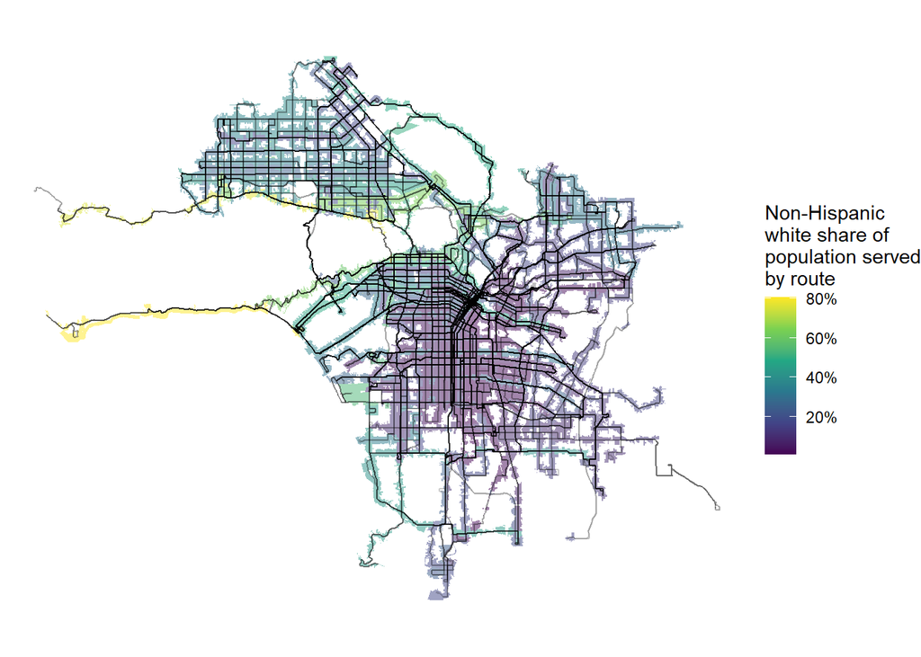

```r
ggplot(transit_walksheds) +
  geom_sf(aes(fill = pct_nh_white), color = NA, alpha = 0.5) +
  geom_sf(data = transit_routes, color = "black", alpha = 0.2) +
 # geom_sf(data = transit_stops, color = "black", size = 0.05, alpha = 0.1) +
  scale_fill_viridis_c(name = "Non-Hispanic\nwhite share of\npopulation served\nby route",
                       breaks = breaks <- seq(0,80, by = 20),
                       labels = paste(breaks, "%", sep = "")) +
  theme_void()
```

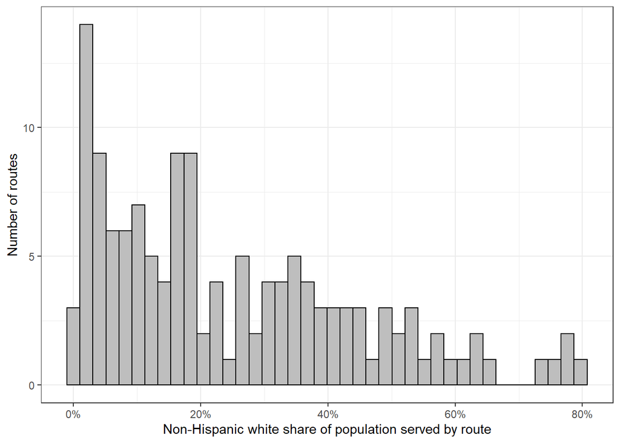

```r
ggplot(transit_walksheds) +
  geom_histogram(aes(x = pct_nh_white),
                 bins = 40,
                 color = "black",
                 fill = "gray") +
  scale_x_continuous(name = "Non-Hispanic white share of population served by route",
                     breaks = breaks <- seq(0,100, by = 20),
                     labels = paste(breaks, "%", sep = "")) +
  scale_y_continuous(name = "Number of routes") +
  theme_bw()
```